# Calculating the accessibility and spatial availability of jobs (*Dissemination area* level)

a methodology for Canadian regions based on the 2021 Census of Population

Bruno Santos & Antonio Paez

2025-04-03

# Introduction

This Rmarkdown file is part of the [**CommuteCA**](https://github.com/dias-bruno/CommuteCA) package. This package was created in conjunction with the office of the [*Research Data Center* at *McMaster University*](https://rdc.mcmaster.ca/), the [*Sherman Centre for Digital Scholarship*](https://scds.ca/) and the [*Mobilizing Justice*](https://mobilizingjustice.ca/).

The Mobilizing Justice project is a multidisciplinary and multi-sector collaboration with the objective of understand and address transportation poverty in Canada and to improve the well-being of Canadians at risk of transport poverty. The Social Sciences and Humanities Research Council (SSRHC) has provided funding for the project, which was created by an unprecedented alliance of academics from various Canadian provinces and institutions, transportation firms, and nonprofit organizations

The [**CommuteCA**](https://github.com/dias-bruno/CommuteCA) R package was created to develop standardized methods for transport analysis in research, particularly for analysis using the [*2021 Census of Population*](https://www12.statcan.gc.ca/census-recensement/index-eng.cfm) from Statistics Canada. We focused our efforts on the [*Commuting Reference Guide*](https://www12.statcan.gc.ca/census-recensement/2021/ref/98-500/011/98-500-x2021011-eng.cfm), which provides valuable variables and information on commuting for the Canadian population aged 15 and older living in private households.

Considering the number of workers and employment opportunities obtained from the [*2021 Census of Population*](https://www12.statcan.gc.ca/census-recensement/index-eng.cfm), this R markdown aims to create a methodology to obtain Hansen-type accessibility (Hansen 1959) and spatial accessibility (Soukhov et al. 2023), for all Canadian provinces and territories, considering different modes of travel.

Hansen, Walter G. 1959. “How Accessibility Shapes Land Use.” *Journal of the American Institute of Planners* 25 (2): 73–76.

Soukhov, Anastasia, Antonio Paez, Christopher D Higgins, and Moataz Mohamed. 2023. “Introducing Spatial Availability, a Singly-Constrained Measure of Competitive Accessibility.” *Plos One* 18 (1): e0278468.

## Suggested Readings

- Soukhov, Anastasia, Antonio Paez, Christopher D Higgins, and Moataz Mohamed. 2023.”Introducing Spatial Availability, a Singly-Constrained Measure of Competitive Accessibility.” *Plos One* 18 (1): e0278468.
- Soukhov, A., Páez, A. (2024). Accessibility analysis for planning applications (Report No. MJ-A2-0002). Mobilizing Justice. https://github.com/soukhova/MJ-Accessibility-Blogs
- Pereira, Rafael H. M.; Herszenhut, Daniel. Introduction to urban accessibility: a practical guide with R. Rio de Janeiro: Ipea, 2023. 152 p. ISBN: 978-65-5635-065-3. DOI: http://dx.doi.org/9786556350653.

## Data

The dataset used in this demonstration is test data produced to replicate the variables available in the original Census of Population. The test data contains 200,000 rows and 17 columns. As in the original census data, each row refers to a respondent and each column refers to a variable.  
The creation of test data was necessary because the surveys provided by Statistics Canada are confidential and cannot be accessed outside of a Research Data Center.

You can check out more information about the Census on the [Dictionary website](https://www12.statcan.gc.ca/census-recensement/2021/ref/dict/index-eng.cfm).

If you want to work with the original Census dataset, the process for obtaining the accessibility measures will be the same as for the test data, except that you will have to update the address of the file in the chunk called *load-census-data*.

A code chunk is an executable part of the R code

For this R markdown, we’ll use the following variables:

The explanation of each variable can be found in the [*2021 Census of Population’s website*](https://www12.statcan.gc.ca/census-recensement/index-eng.cfm).

Census variables used in this R markdown.

| **Variable** | **Description** |
| --- | --- |
| PRCDDA | Refers to the dissemination area (DA) of current residence. |
| Pr | Refers to the province or territory of current residence. |
| CMA | Census metropolitan area or census agglomeration of current residence. |
| PCD | Census division of current residence. |
| CompW1 | Weight for the households and dwellings universes. |
| LBR_FORC | This variable refers to whether a person was employed, unemployed or not in the labour force. |
| PWDA | Place of work dissemination area. |
| PWPR | Place of work province. |
| PWCMA | Census metropolitan area or census agglomeration of place of work. |
| PWCD | Place of work census division. |
| PWDUR | Commuting duration, it refers to the length of time, in minutes, usually required by a person to travel to their place of work. |
| PwMode | Main mode of commuting’ refers to the main mode of transportation a person uses to travel to their place of work. |

A dissemination area (DA) is a small, relatively stable geographic unit composed of one or more adjacent dissemination blocks. It is the smallest standard geographic area for which all census data are disseminated. DAs cover all Canadian territory.

We will also use the travel time table created in the previous step, in the R markdown called *03_travel_times.Rmd*..

Although we have provided test census data for all Canadian provinces and territories, we have produced a travel table only for the city of Toronto. So if you want to test the methodology for other cities or regions, you’ll have to generate a travel time for the corresponding study area with *01_travel_times.Rmd*

The travel times table has the following variables:

Travel time table variables used in this R markdown.

| **Variable** | **Description** |
| --- | --- |
| PRCDDA | Refers to the DA defined as the origin. |
| CMAUID | Census metropolitan area or census agglomeration of the DA defined as the origin. |
| PWDA | Refers to the DA defined as the destination. |
| travel_time | Estimated travel time in minutes from origin to destination. |
| PwMode | Transportation mode used to calculate the travel time. |

# Measuring accessibility

In transportation research, accessibility is a location-based measure that refers to the potential of a *population* to reach spatially distributed *opportunities*. These often include destinations that are important to ensure that all members of society can lead plentiful, meaningful lives, such as jobs, parks, cultural activities, health services, education, and, in our case, *jobs*.

Location-based metrics measure accessibility as a characteristic of a given location, assuming that all people in the same location have equal access to activities distributed throughout the city. Such measures are sensitive to land use and transportation factors related to the spatial distribution of activities and the configuration and performance of the transportation network. However, they do not take into account the individual characteristics of people.

We strongly recommend reading the report by Soukhov and Páez (2024), which provides a detailed explanation of the components of accessibility analysis, as well as their possible uses in equity planning

For our purposes, the population is the people residing in some origin (a DA) on the date of May 11, 2021, and the opportunities are the jobs located in a given destination (a DA) with which the population interacts. The population uses a mode of transportation (for example, walking, cycling, public transit, car, motorcycle) to reach their destination, with a certain travel cost (distance, time, monetary cost or a combination of several factors).

Date used as reference for the 2021 Population Census

The result of the accessibility model is a value assigned to each spatial unit - usually at the origin. Areas with high accessibility values have more connections and are closer to more opportunities, while areas with low values have the opposite.

## Hansen-type accessibility (HT)

The measure of Hansen (1959) considers that the sum of opportunities in each destination in gradually discounted as the travel cost increases. In this case, opportunities that area easier to access counts more for the measure. Many accessibility measures derive from this work (Soukhov and Páez 2024), according to the equation:

Hansen, Walter G. 1959. “How Accessibility Shapes Land Use.” *Journal of the American Institute of Planners* 25 (2): 73–76.

Soukhov, Anastasia, and Antonio Páez. 2024. “Accessibility Analysis for Planning Applications.” MJ-A2-0002. Mobilizing Justice. https://github.com/soukhova/MJ-Accessibility-Blogs.

$$HT_i = \sum_{j=1}^{J}O_j \cdot f(c_{ij})$$

Where:

- $i$ and $j$: set of spatial units in a region.
- $O_j$: number of opportunities $O$ at destinations $j$.
- $f(c_{ij})$: travel cost function, also called decay-function or impedance function.
- $HT_i$: accessibility score at the origin $i$ being represented by the weighted sum of opportunities considering all destinations $O_j$.

## Impedance functions

The impedance function $f(c_{ij})$ reveals important information about the travel behavior of the population, as it represents the relationship between the “population” at an origin and where they usually go, want to go, or can go to reach the “opportunities” at the destinations. Therefore, defining the impedance function is extremely important.

The decay rate of the impedance function needs to be calibrated if one wants the accessibility estimates to be representative of the people’s travel behavior. In our case, we’ll use the Census data in the calibration process.

Soukhov and Páez (2024) reviewed commonly used impedance functions $f(\bullet)$ in accessibility research, explaining their impacts on the summation of opportunities at specific travel costs $c_{ij}$. In this study, we will explore the following functions to determine the impedance function that best fits our data: [exponential](https://en.wikipedia.org/wiki/Exponential_distribution), [gamma](https://en.wikipedia.org/wiki/Gamma_distribution), [log-normal](https://en.wikipedia.org/wiki/Log-normal_distribution), [normal](https://en.wikipedia.org/wiki/Normal_distribution), and [uniform](https://en.wikipedia.org/wiki/Continuous_uniform_distribution).

Soukhov, Anastasia, and Antonio Páez. 2024. “Accessibility Analysis for Planning Applications.” MJ-A2-0002. Mobilizing Justice. https://github.com/soukhova/MJ-Accessibility-Blogs.

## Spatial Availability

Often, access to opportunities is affected by competition among many people seeking the same opportunity, not just by geographic proximity and transportation costs (R. H. Pereira and Herszenhut 2023). If competition is not taken into account, it is assumed that the opportunity is equally available to all individuals who seek the opportunity and can reach it - which is not a problem if the opportunity of interest is not exclusive, so that use by one person does not prevent use by another.

Pereira, Rafael HM, and Daniel Herszenhut. 2023. “Introduction to Urban Accessibility: A Practical Guide with r.”

Hansen (1959), apart from his innovative implementation of an accessibility measure, does not consider competition in the distribution of opportunities. Also, this measure is considered an unconstrained measure, which means that the same opportunity can be allocated to different origins, making it difficult to interpret the result. Another difficulty in interpreting the result is caused by the way in which the number of job opportunities is discounted by the cost of travel.

Hansen, Walter G. 1959. “How Accessibility Shapes Land Use.” *Journal of the American Institute of Planners* 25 (2): 73–76.

With the goal of including competition in the accessibility measures and constraining the opportunity calculation to a known quantity, (Soukhov et al. 2023) created the *spatial availability* measure. This study also provides a more interpretable result because it guarantees that the measures are summed to a predetermined value, e.g. the total number of jobs in a region, so that each value at the origin can be meaningfully related to this total.

Soukhov, Anastasia, Antonio Paez, Christopher D Higgins, and Moataz Mohamed. 2023. “Introducing Spatial Availability, a Singly-Constrained Measure of Competitive Accessibility.” *Plos One* 18 (1): e0278468.

$$SA_i = \sum_{j=1}^{J}O_j \cdot F_{ij}^t$$

Where:

- $SA_i$ is the number of spatially available opportunities from the perspective of $i$.
- $O_j$ is the number of opportunities $O$ at the destination $j$.
- $F_{ij}$ is a balancing factor that depends on the population and cost of travel in the system.

Being $f(c_{ij})$ the impedance function and $P_i$ is the population at origin i, the balancing factor $F_{ij}$ consists of two components:

- $F_{i}^{p}$, a population-based balancing factor that allocate opportunities to $i$ in proportion to the size of the population of the different competing centers. With:

$$F_{i}^{p} = \frac{P_i}{\sum_{i}P_i}$$

- and $F_{ij}^{c}$, an impedance-based balancing factor that represents the cost of reaching opportunities. With:

$$F_{i}^{c} = \frac{f_{(c_ij)}}{\sum_{i}f_{(c_{ij})}}$$
We can obtain $F_{ij}$ by:
$$F_{ij}^{t} = \frac{F_i^{p} \cdot F_{ij}^{(c_ij)}}{\sum_{i}F_i^{p} \cdot F_{ij}^{(c_ij)}}$$

# Let’s code!

The methodology for obtaining the accessibility measures using the Canadian Census consists of the following steps:

1. First, we estimate the travel time for each transportation mode using the [{r5r}](https://cloud.r-project.org/web/packages/fitdistrplus/index.html) package (R. H. M. Pereira et al. 2021), considering all possible combinations of dissemination areas of the selected study area. The methodology used to obtain the travel time table is in the *01_travel_times.Rmd*.

   Pereira, Rafael H. M., Marcus Saraiva, Daniel Herszenhut, Carlos Kaue Vieira Braga, and Matthew Wigginton Conway. 2021. “R5r: Rapid Realistic Routing on Multimodal Transport Networks with R5 in r.” *Findings*. https://doi.org/10.32866/001c.21262.
2. After this, we extract the commute time to work declared by the Census respondents, in order to calibrate the impedance functions for each transportation mode.
3. We then apply the impedance functions to the travel time table.
4. Next, we create a land use table. This table contains the labour force population and the number of job opportunities for each dissemination area.
5. We join the travel time and labour force tables, creating the accessibility table. This last table has all the data needed to carry out the accessibility analysis.
6. Finally, we perform the Hansen accessibility type and the spatial availability.

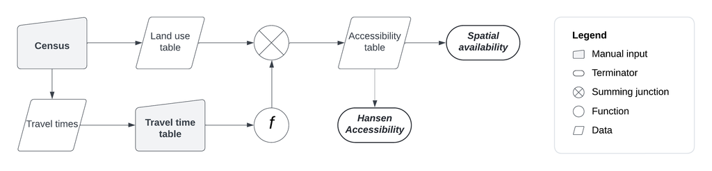

Methodology to obtain the accessibility measures.

Load the packages:

```r
library(CommuteCA)
library(dplyr)# A Grammar of Data Manipulation
library(fitdistrplus) # Help to Fit of a Parametric Distribution to Non-Censored or Censored Data
library(scales) # Scale data column-wise in a computationally efficient way
library(here) # enable easy file referencing in project-oriented workflows
```

Reading census data and creating a R data frame:

For this demonstration, we will use the case of the city of Toronto. If you want to use the other options, the original data from the Census in an RDC office or the test data for all locations in Canada, *update* the address in the chunk.

```r
# For the original Census data set
# files_address <- paste0(here(),"insert-the-RDC-address.csv!!!")
# census <- read.csv(files_address, header = TRUE)
```

If the original Census dataset available in the RDC is not in .csv (comma-separated values) format but is instead provided in other formats such as SPSS, SAS, or SAS Data, you can use the foreign package (a built-in R library) to import it:

```r
# library(foreign)
# foreign::read.dta(files_address) # For Stata
# foreign::read.spss(files_address) # For SPSS
# There are many other options! You can search for this library in the 'Packages' window and explore additional functions for reading your file.
```

Or if you have installed *CommuteCA*, you can access the *test* data:

```r
data("census_test_data")
census <- census_test_data
```

⚠️**NOTE:** If the code above did not run correctly, you probably are experiencing a file address error. Try to identify the correct address and update the chunk named `census-file-address` to continue.

The original census dataset has a wide variety of attributes. However, we will only work with a selection of these variables. The next chunk selects only the variables previously chosen for our analysis, reducing the size of the dataframe and making data processing faster:

```r
census <- census %>%
          dplyr::select("PRCDDA",
                 "Pr",
                 "CMA",
                 "PCD",
                 "CompW1",
                 "LBR_FORC",
                 "PWDA",
                 "PWPR",
                 "PWCMA",
                 "PWCD",
                 "PWDUR",
                 "PWDist",
                 "PwMode")
```

Some of these variables should have been read as a factor variable. The next chunk corrects this problem by turning them into factors:

```r
census <- census %>%
          mutate_at(c("PRCDDA",
                 "Pr",
                 "CMA",
                 "PCD",
                 "LBR_FORC",
                 "PWDA",
                 "PWPR",
                 "PWCMA",
                 "PWCD"), as.factor)
```

View summary statistics from the data frame:

```r
summary(census[,1:12])
```

```
##       PRCDDA             Pr             CMA              PCD
##  35204733:  1367   35     :94545   535    : 61375   3520   : 52650
##  62040059:  1280   24     :27084   462    :  9487   4811   :  7176
##  35204634:  1081   59     :25412   999    :  7248   5915   :  5276
##  35204479:  1043   48     :19870   835    :  7061   4806   :  5164
##  48160244:   973   13     : 7612   505    :  6369   3519   :  3314
##  48160278:   937   47     : 7386   933    :  5276   4816   :  3084
##  (Other) :193319   (Other):18091   (Other):103184   (Other):123336
##      CompW1     LBR_FORC          PWDA             PWPR           PWCMA
##  Min.   : 100   -3:  5948   -3      : 49749   35     :70930   -3     :49749
##  1st Qu.: 650   1 :150251   35204733:  1012   -3     :49749   535    :46398
##  Median :1200   2 : 29857   62040059:   957   24     :20604   999    :22255
##  Mean   :1199   3 : 13944   35204634:   828   59     :18922   462    : 6614
##  3rd Qu.:1747               35204479:   756   48     :14773   835    : 4714
##  Max.   :2299               35203174:   634   47     : 5720   505    : 4325
##                             (Other) :146064   (Other):19302   (Other):65945
##       PWCD           PWDUR            PWDist
##  -3     :49749   Min.   : -3.00   Min.   :   -3
##  3520   :39701   1st Qu.: -3.00   1st Qu.:   -3
##  4811   : 4940   Median : 36.00   Median :11946
##  5915   : 3861   Mean   : 46.82   Mean   :15849
##  4806   : 3580   3rd Qu.: 84.00   3rd Qu.:28629
##  3519   : 2801   Max.   :167.00   Max.   :50000
##  (Other):95368
```

It’s possible to filter the data frame by administrative (province and/or census division) and/or statistical (census metropolitan areas and census agglomerations). The chunk below shows how to make this procedure:

As said before, we will perform our analysis for the city of Toronto. If you want to select a specific area to work, uncomment the code above that applies to your case and select the apropriate code of your interest unit. Please, check the dictionary to have more informations about the [provinces code](https://www12.statcan.gc.ca/census-recensement/2021/ref/dict/tab/index-eng.cfm?ID=t1_8), [census divisions](https://www12.statcan.gc.ca/census-recensement/2021/ref/dict/az/Definition-eng.cfm?ID=geo008), and [census metropolitan areas](https://www12.statcan.gc.ca/census-recensement/2021/ref/dict/az/Definition-eng.cfm?ID=geo009)

```r
code <- 3520 # census division of Toronto

# # Filtering by province
# census_filtered <- census %>%
#                   filter(PR == code & (PWPR == code| LBR_FORC == 2)) # Only select respondents who live in province = code
# census <- census %>% filter(PR == code) # Only select respondents who live in  PR = code (Census base)

#
# # Filtering by census metropolitan areas and census agglomerations
# census_filtered <- census %>%
#                   filter(CMA == code & (PWCMA == code| LBR_FORC == 2)) # Only select respondents who live in cma = code
# census <- census %>% filter(CMA == code) # Only select respondents who live in  cma = code (Census base)


# # Filtering by census division
 census_filtered <- census %>%
                    filter(PCD == code  & (PWCD == code | LBR_FORC == 2)) # Only select respondents who live in  Toronto
 census <- census %>% filter(PCD == code) # Only select respondents who live in  Toronto (Census base)
```

According to the census code book, the variable ‘PwMode’ has the following possible values:

- -3: Not applicable.
- 1: Car, truck or van - as a driver.
- 2: Car, truck or van - as a passenger.
- 3: Bus.
- 4: Subway or elevated rail.
- 5: Light rail, streetcar or commuter train.
- 6: Passenger ferry.
- 7: Walked.
- 8: Bicycle.
- 9: Motorcycle, scooter or moped.
- 10: Other method.

We’ll rename the travel modes to facilitate the readability of the data. Additionally, we’ll remove from our analysis travel modes signed as ‘Other methods’:

```r
census_filtered <- census_filtered  %>%
                   filter(PwMode < 10) %>%
                   mutate(PwMode = case_when(PwMode > 0 & PwMode <= 2 ~ "Car/motor",
                                             PwMode == 9 ~ "Car/motor",
                            PwMode >= 3 & PwMode <= 6  ~ "Transit",
                            PwMode == 7  ~ "Walk",
                            PwMode == 8  ~ "Bike"),

         PwMode = factor(PwMode, levels = c("Bike", "Walk", "Car/motor", "Transit")))

census <- census  %>%
                   mutate(PwMode = case_when(PwMode > 0 & PwMode <= 2 ~ "Car/motor",
                                             PwMode == 9 ~ "Car/motor",
                            PwMode >= 3 & PwMode <= 6  ~ "Transit",
                            PwMode == 7  ~ "Walk",
                            PwMode == 8  ~ "Bike"),

         PwMode = factor(PwMode, levels = c("Bike", "Walk", "Car/motor", "Transit")))
```

According to the Census 2021, an ‘Employed’ person refers to those who, during the reference period, had a labour force status of ‘employed.’. In addition, the labour force is made up of the employed population and the unemployed population. This variable can assume the values:

Those who, during the reference period: (a) Did any work at all at a job or business, that is, paid work in the context of an employer-employee relationship, or self-employment. This also includes persons who did unpaid family work, which is defined as unpaid work contributing directly to the operation of a farm, business or professional practice owned and operated by a related member of the same household; or (b) Had a job but were not at work due to factors such as their own illness or disability, personal or family responsibilities, vacation or a labour dispute. This category excludes persons not at work because they were on layoff or between casual jobs, and those who did not then have a job (even if they had a job to start at a future date).

- -3: Not Applicable, < 15 years
- 1: In Labour Force, Employed
- 2: In Labour Force, Unemployed
- 3: Not in Labour Force

Each employee also declares in which DA their workplace is located. This information is important for the accessibility analysis, as it allows us to count the number of job opportunities in each DA.

```r
# Employed respondents
census_employed <- census_filtered %>%
                   filter(LBR_FORC == 1)

census_labour_force <- census_filtered %>%
                   filter(LBR_FORC == 1 | LBR_FORC == 2)
```

# Trip length distribution

All of the impedance functions mentioned require the analyst to define parameters. One useful technique is to create a trip length distribution (TLD) using empirically observed origin-destination travel survey data. A TLD reflects observed travel patterns: specifically, the probability of an observed trip of a given travel cost occurring for the population in a region of interest. Based on the TLD, we can select the most appropriate theoretical PDF forms (e.g., uniform, exponential, gamma), adjust the associated parameters, and use the calibrated theoretical PDF to incorporate the assumptions about the population’s travel behavior into the accessibility calculation.

Soukhov and Páez (2024) demonstrated the process of calibrating and selecting the best distribution to represent an impedance function based on travel flows from workers who live and work (full-time) within the City of Hamilton. The authors used the data from the R data package [{TTS2016R}](https://soukhova.github.io/TTS2016R/) and the R package [{fitdistrplus}](https://cloud.r-project.org/web/packages/fitdistrplus/index.html) to generate parameters that best fit the TLD the parameters of the uniform, exponential, and gamma functions as closely to the TLD.

Soukhov, Anastasia, and Antonio Páez. 2024. “Accessibility Analysis for Planning Applications.” MJ-A2-0002. Mobilizing Justice. https://github.com/soukhova/MJ-Accessibility-Blogs.

The next chunks of code of this section aim to calibrate the PDF function based on the 2021 Census Data.

## Empirical travel time

Extracting the travel times for each mode:

```r
census_employed$PWDUR[census_employed$PWDUR == 0] <- 0.1 # Besides it is possible a travel-time of 0 minutes, we need to substitute this value because the functions used bellow to define the best impedance function does not accept zero as a valid value. Because of this, we'll change all zero values to 0.1 minute travel-time.

# Bike travel times
df_tt_bike <- census_employed %>%
  filter(PwMode == 'Bike') %>%
  dplyr::select(PWDUR, CompW1) %>%
  mutate(mode = "Bike")

# Car travel times
df_tt_car <- census_employed %>%
  filter(PwMode == 'Car/motor') %>%
  dplyr::select(PWDUR, CompW1) %>%
  mutate(mode = "Car/motor")

# Transit travel times
df_tt_transit <- census_employed %>%
  filter(PwMode == 'Transit') %>%
  dplyr::select(PWDUR, CompW1) %>%
  mutate(mode = "Transit")

# Walk travel times
df_tt_walk <- census_employed %>%
  filter(PwMode == 'Walk') %>%
  dplyr::select(PWDUR, CompW1) %>%
  mutate(mode = "Walk")
```

Creating a data frame with the all empirical travel times:

```r
# Bind the empirical trip length distribution:
tld_empirical <- rbind(df_tt_bike,
      df_tt_car,
      df_tt_transit,
      df_tt_walk) %>%
  mutate(mode = factor(mode,
                       levels = c("Bike", "Walk", "Car/motor", "Transit")),
         distribution = "empirical")

tld_empirical$PWDUR <- as.numeric(tld_empirical$PWDUR)
```

## Theoretical travel time

Now that we already have the travel times for each mode of transportation, we will try to create a impedance function that better describes the travel pattern of the respondents in each mode. To do so, we’ll first create a function that based on the lowest Akaike Information Criterion (AIC), selects the better function between the distributions: [exponential](https://en.wikipedia.org/wiki/Exponential_distribution), [gamma](https://en.wikipedia.org/wiki/Gamma_distribution), [log-normal](https://en.wikipedia.org/wiki/Log-normal_distribution), [normal](https://en.wikipedia.org/wiki/Normal_distribution), and [uniform](https://en.wikipedia.org/wiki/Continuous_uniform_distribution).

The Akaike Information Criterion (AIC) estimates prediction error and model quality for a given data set.

We’ll use the [{fitdistrplus}](https://cloud.r-project.org/web/packages/fitdistrplus/index.html) to determine the parameters that best fit the TLD. The Moment Matching Estimation (MME) fitting method and the Nelder-Mead direct optimization algorithm are used (Delignette-Muller and Dutang 2015).

Delignette-Muller, Marie Laure, and Christophe Dutang. 2015. “Fitdistrplus: An r Package for Fitting Distributions.” *Journal of Statistical Software* 64 (4): 1–34. https://doi.org/10.18637/jss.v064.i04.

```r
# Select the distribution function based on the lowest AIC value
lowest_aic <- function(values){

  min_aic <- min(values)

  if(!is.na(lnorm_$aic) & min_aic == lnorm_$aic){
    choosen_f <- lnorm_
  }

  else if  (!is.na(gamma_$aic) & min_aic == gamma_$aic){
    choosen_f <- gamma_
  }

  else if  (!is.na(unif_$aic) & min_aic == unif_$aic){
    choosen_f <- unif_
  }

  else if  (!is.na(norm_$aic) & min_aic == norm_$aic){
    choosen_f <- norm_
  }
  else if  (!is.na(exp_$aic) & min_aic == exp_$aic){
    choosen_f <- exp_
  }

  return(choosen_f)
}

# Test the distributions
test_distributions <- function(x, weights){
  gamma_ <<- fitdistrplus::fitdist(data=x, "gamma", method="mme", weights = weights)
  lnorm_ <<- fitdistrplus::fitdist(data=x, "lnorm", method="mme", weights = weights)
  norm_ <<- fitdistrplus::fitdist(data=x, "norm", method="mme", weights = weights)
  exp_ <<- fitdistrplus::fitdist(data=x, "exp", method="mme", weights = weights)
  unif_ <<- fitdistrplus::fitdist(data=x, "unif", method="mme", weights = weights)

  values <- c(lnorm_$aic, gamma_$aic, unif_$aic, norm_$aic, exp_$aic)
  values <- values[!is.na(values)]

  chosen_function <- lowest_aic(values)

  return(chosen_function)
}

test_distributions_weighted <- function(x, weights){
  gamma_ <<- fitdistrplus::fitdist(data = x, "gamma", method="mme", weights = weights)
  lnorm_ <<- fitdistrplus::fitdist(data = x, "lnorm", method="mme", weights = weights)
  norm_ <<- fitdistrplus::fitdist(data = x, "norm", method="mme", weights = weights)
  exp_ <<- fitdistrplus::fitdist(data = x, "exp", method="mme", weights = weights)
  unif_ <<- fitdistrplus::fitdist(data = x, "unif", method="mme", weights = weights)

  values <- c(lnorm_$aic, gamma_$aic, unif_$aic, norm_$aic, exp_$aic)
  values <- values[!is.na(values)]

  chosen_function <- lowest_aic(values)

  return(chosen_function)
}
```

Obtaining the theoretical impedance function for the bike mode:

```r
mode <- 'Bike'
bike_function <- test_distributions(x = tld_empirical[tld_empirical$mode == mode, ]$PWDUR,
                                    weights = tld_empirical[tld_empirical$mode == mode, ]$CompW1)
bike_function
```

```
## Fitting of the distribution ' lnorm ' by matching moments
## Parameters:
##          estimate Std. Error
## meanlog 2.8223186 0.03378448
## sdlog   0.8192167 0.04069346
```

Obtaining the theoretical impedance function for the car mode:

```r
mode <- 'Car/motor'
car_function <- test_distributions(x = tld_empirical[tld_empirical$mode == mode, ]$PWDUR,
                                    weights = tld_empirical[tld_empirical$mode == mode, ]$CompW1)
car_function
```

```
## Fitting of the distribution ' gamma ' by matching moments
## Parameters:
##        estimate  Std. Error
## shape 4.5594703 0.055624439
## rate  0.1043289 0.001328791
```

Obtaining the theoretical impedance function for the transit mode:

```r
mode <- 'Transit'
transit_function <- test_distributions(x = tld_empirical[tld_empirical$mode == mode, ]$PWDUR,
                                    weights = tld_empirical[tld_empirical$mode == mode, ]$CompW1)
transit_function
```

```
## Fitting of the distribution ' gamma ' by matching moments
## Parameters:
##         estimate  Std. Error
## shape 4.27186193 0.057273593
## rate  0.07637462 0.001071426
```

Obtaining the theoretical impedance function for the walk mode:

```r
mode <- 'Walk'
walk_function <- test_distributions(x = tld_empirical[tld_empirical$mode == mode, ]$PWDUR,
                                    weights = tld_empirical[tld_empirical$mode == mode, ]$CompW1)
walk_function
```

```
## Fitting of the distribution ' norm ' by matching moments
## Parameters:
##      estimate Std. Error
## mean 32.93213  0.3487943
## sd   13.81155  0.2466345
```

The chunk below aims to create functions to graphically display the theoretical values obtained in the chunks above and also create a new data based on the theoretical distribution for each transportation mode:

```r
# For Displaying theoretical data

visualize_impedance <- function(mode_function, travel_cost, name_mode){

  x <- data.frame(t = seq(1, max(travel_cost), 1))

  # lnorm impedance
  if(mode_function$distname == "lnorm"){
      x <- x %>%
      mutate(f = dlnorm(t,
                    meanlog = mode_function$estimate[1],
                    sdlog = mode_function$estimate[2]),
         mode = name_mode)

  # Unif impedance
  } else if(mode_function$distname == "unif") {
    x <- x %>%
    mutate(f = dunif(t,
                     min=0,
                     max=mode_function$estimate[2]), #already scaled from 1 to 0
         mode = name_mode)

  # Exponential impedance
  } else if(mode_function$distname == "exp") {
    x <- x %>%
    mutate(f = dexp(t,
                    rate = mode_function$estimate), #|> scales::rescale(),
         mode = name_mode)

  # Gamma impedance
  } else if (mode_function$distname == "gamma"){
    x <- x %>%
        mutate(f = dgamma(t,
                    shape = mode_function$estimate[1],
                    rate = mode_function$estimate[2]),
         mode = name_mode)

  # Norm impedance
  } else if (mode_function$distname == "norm"){
        x <- x %>%
        mutate(f = dnorm(t,
                    mean = mode_function$estimate[1],
                    sd = mode_function$estimate[2]),
         mode = name_mode)
        }

  return(x)
}


# To generate the theoretical data

generate_impedance <- function(mode_function, travel_cost){

  f <- 0

  # lnorm impedance
  if(mode_function$distname == "lnorm"){
  f <- dlnorm(travel_cost,
                    meanlog = mode_function$estimate[1],
                    sdlog = mode_function$estimate[2])
  }

  # Unif impedance
  else if(mode_function$distname == "unif") {
   f <- dunif(travel_cost,
                     min=0,
                     max=mode_function$estimate[2])

  # Exponential impedance
  } else if(mode_function$distname == "exp") {
    f <- rescale(dexp(travel_cost,
                    rate = mode_function$estimate))
      # Gamma impedance
  } else if (mode_function$distname == "gamma"){
    f <- dgamma(travel_cost,
                    shape = mode_function$estimate[1],
                    rate = mode_function$estimate[2])
  # Norm impedance
  } else if (mode_function$distname == "norm"){
        f <- dnorm(travel_cost,
                    mean = mode_function$estimate[1],
                    sd = mode_function$estimate[2])
        }

  return(f)
}
```

Building the theoretical values for each mode based on the best impedance function for each mode:

```r
# Theoretical values for bike mode
mode <- 'Bike'
theo_bike <- visualize_impedance(mode_function = bike_function,
                                 travel_cost = tld_empirical[tld_empirical$mode == mode, ]$PWDUR,
                                 name_mode = "Bike")

# Theoretical values for car mode
mode <- 'Car/motor'
theo_car <- visualize_impedance(mode_function = car_function,
                                travel_cost = tld_empirical[tld_empirical$mode == mode, ]$PWDUR,
                                name_mode = "Car/motor")

# Theoretical values for transit mode
mode <- 'Transit'
theo_transit <- visualize_impedance(mode_function = transit_function,
                                    travel_cost = tld_empirical[tld_empirical$mode == mode, ]$PWDUR,
                                    name_mode = "Transit")

# Theoretical values for walk mode
mode <- 'Walk'
theo_walk <- visualize_impedance(mode_function = walk_function,
                                 travel_cost = tld_empirical[tld_empirical$mode == mode, ]$PWDUR,
                                 name_mode = "Walk")

# Bind the theoretical trip length distribution:
tld_theoretical <- rbind(theo_bike,
      theo_car,
      theo_transit,
      theo_walk) %>%
  mutate(mode = factor(mode,
                       levels = c("Bike", "Walk", "Car/motor", "Transit")))
```

Plotting the theoretical (black lines) and the empirical travel time distributions (bars):

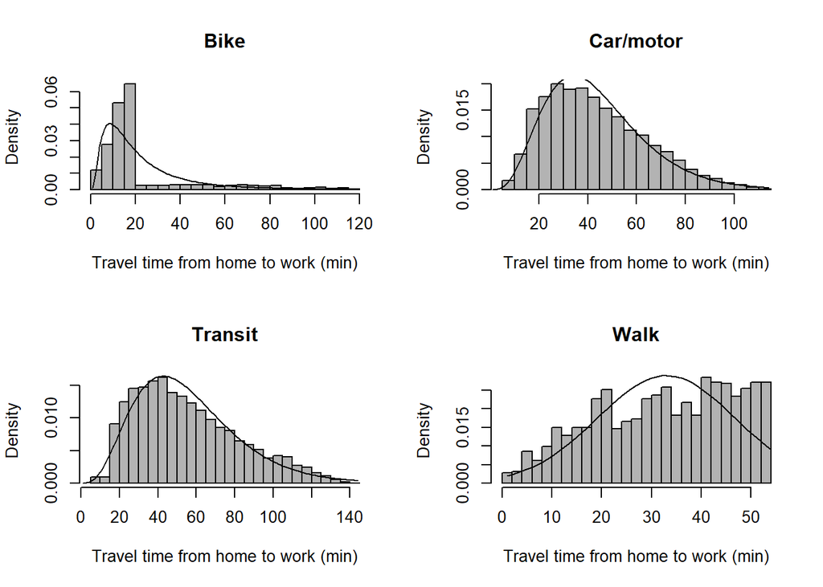

```r
par(mfrow = c(2, 2))  # Arrange plots in a 2x2 grid

# Loop through each mode
for (mode in unique(tld_empirical$mode)) {
  # Subset empirical and theoretical data for the current mode
  empirical_subset <- tld_empirical[tld_empirical$mode == mode, ]
  theoretical_subset <- tld_theoretical[tld_theoretical$mode == mode, ]

  # Create histogram for empirical data
  hist(empirical_subset$PWDUR, freq = FALSE, col = "grey70", breaks = 30, main = paste(mode),
       xlab = "Travel time from home to work (min)", ylab = "Density")

  # Add theoretical curve
  lines(theoretical_subset$t, theoretical_subset$f)
}
```

```r
# Reset plotting parameters
par(mfrow = c(1, 1))
```

# Reading and preparing the travel matrix table

Reading the travel time table created in the *03_travel_times.Rmd*:

*If you are working with another study area or with the original Census data, don’t forget to change the address file for the next chunk.*

```r
ttm <- read.csv(paste0(here(),"/data-raw/aux-files/PCD3520/DA/travel_times/ttm.csv")) # Travel time table address
```

Visualizing some statistics about the travel time matrix:

```r
ttm %>%
  group_by(PwMode) %>%
  summarize(mean_tt = mean(travel_time),
            median_tt = median(travel_time),
            min_tt = min(travel_time),
            max_tt = max(travel_time))
```

```
## # A tibble: 4 × 5
##   PwMode    mean_tt median_tt min_tt max_tt
##   <chr>       <dbl>     <dbl>  <int>  <int>
## 1 Bike        102.         98      0    240
## 2 Car/motor    20.7        21      0    240
## 3 Transit      75.2        72      0    239
## 4 Walk        148.        154      0    240
```

Bringing weights information from the Census table:

```r
ttm <- ttm %>%
   mutate(from_id = as.factor(from_id),
          to_id = as.factor(to_id),
          PwMode = as.factor(PwMode))

weights_df <- census_employed %>%
  group_by(PRCDDA,
           PWDA,
           PwMode) %>%
  summarize(weights = sum(CompW1),
            .groups = "drop")

ttm <- ttm %>%
  left_join(weights_df, by = c("from_id" = "PRCDDA", "to_id" = "PWDA", "PwMode" = "PwMode"))

if (anyNA(ttm$weights)) {
  ttm$weights[is.na(ttm$weights)] <- 0
}

ttm$weights <- round(ttm$weights)

ttm[ttm$travel_time == 0,]$travel_time <- 0.1
```

The value of impedance function for each origin-destination-mode will be obtained using travel time of the ttm table and the best impedance function based on the empirical length distributions..

```r
ttm_f <- data.frame()

for(pcd in unique(ttm$PCD)){

  # PCD data set
  ttm_pcd <- ttm[ttm$PCD == pcd, ]

  cat("Obtaining the impedance function for the PCD: ", code, "\n")

  for(mode in (unique(ttm_pcd$PwMode))){

    cat("Transportation mode: ", mode, "\n")

    ttm_pcd_mode <- ttm_pcd[ttm_pcd$PwMode == mode, ]

    if(length(ttm_pcd_mode$travel_time) == 1){

      ttm_pcd_mode$dist <- 'No dist.'

      ttm_pcd_mode$f <- 1

      ttm_f <- rbind(ttm_f, ttm_pcd_mode)

    } else {

      best_mode_function <- test_distributions(x = ttm_pcd_mode$travel_time,
                                                        weights = ttm_pcd_mode$weights)

      ttm_pcd_mode$dist <- best_mode_function$distname

      ttm_pcd_mode$f <- generate_impedance(mode_function = best_mode_function,
                                           travel_cost = ttm_pcd_mode$travel_time)

      ttm_f <- rbind(ttm_f, ttm_pcd_mode)

    }

  }

}
```

```
## Obtaining the impedance function for the PCD:  3520
## Transportation mode:  Bike
```

```
## Transportation mode:  Car/motor
```

```
## Transportation mode:  Transit
```

```
## Transportation mode:  Walk
```

# Generating the Land-use table

We now need to determine the labour force and job opportunities for each spatial unit. In our analysis, we will use the DA as the spatial unit of reference, since the DA is the most detailed spatial unit used by the Population Census to aggregate the data.

Creating the labour force table:

```r
# Total non commuters population by PRCDDA
non_commuters <- census_labour_force %>%
  filter(PWDUR == -3) %>%
  group_by(PRCDDA) %>%
  summarize(all_non_commuters = sum(CompW1),
            .groups = "drop")

# Total commuters by PRCDDA and PwMode
commuters <- census_employed %>%
  filter(!is.na(PwMode)) %>%
  group_by(PRCDDA, PwMode) |>
  summarize(commuters_mode = sum(CompW1),
            .groups = "drop")

# commuter population by PRCDDA
commuters <- commuters %>%
            group_by(PRCDDA) %>%
            mutate(all_commuters = sum(commuters_mode))

# Allocating the non_commuters according to the share of each population mode

grid_exp_non_commuters <-
  expand.grid(PRCDDA = unique(non_commuters$PRCDDA), PwMode = unique(commuters$PwMode))

non_commuters <- left_join(non_commuters, grid_exp_non_commuters)

labour_force <- commuters %>%
  full_join(non_commuters, by = c("PRCDDA", "PwMode"))

labour_force[is.na(labour_force$all_non_commuters),]$all_non_commuters <- 0

labour_force["perc_mode"] <- labour_force$commuters_mode/labour_force$all_commuters

## For cases when the DA there's only non_commuters respondents

general_perc_mode <- census_employed %>%
  filter(!is.na(PwMode)) %>%
  group_by(PwMode) %>%
  summarise(general_pop_mode = sum(CompW1)) %>%
  mutate(general_pop = sum(general_pop_mode),
         pc = general_pop_mode/general_pop)

for(mode in unique(commuters$PwMode)){
  labour_force[is.na(labour_force$perc_mode) & labour_force$PwMode == mode, ]$perc_mode <- general_perc_mode[general_perc_mode$PwMode == mode,]$pc
}

labour_force[is.na(labour_force$commuters_mode),]$commuters_mode <- 0
labour_force[is.na(labour_force$all_commuters),]$all_commuters <- 0

# Updating the labour force
labour_force <- labour_force %>%
  mutate(labour_force = ((all_non_commuters * perc_mode) + commuters_mode))
```

```r
labour_force <- labour_force[,c("PRCDDA", "PwMode", "labour_force")]
```

Creating the jobs table:

```r
# Total job opportunities
jobs <- as.data.frame(census_employed) |>
  group_by(PWDA) |>
  summarize(jobs = sum(CompW1),
            .groups = "drop")

grid_exp_jobs <-
  expand.grid(PWDA = unique(jobs$PWDA), PwMode = unique(commuters$PwMode))

jobs <- left_join(jobs, grid_exp_jobs)
```

Creating a land use data frame with the following information for each DA: mode of transportation, number of potential workers by mode, and number of jobs.

```r
land_use <- data.frame(expand.grid(PRCDDA = union(census_labour_force$PRCDDA, census_employed$PWDA), PwMode = unique(commuters$PwMode)))

land_use <- land_use %>%
  full_join(labour_force, by = c("PRCDDA","PwMode")) %>%
  full_join(jobs, by = c("PRCDDA" = "PWDA","PwMode"))
```

It is possible that the table junction results in NA values for the labour force or jobs column. Because of this, we’ll assign a 0 value to lines with NA values in number of jobs/labour force.

Imagine an industrial DA where there are a number of job opportunities, but no one lives there. As another example, we could take a strictly residential DA with many potential labour force living there, but no job opportunities. In the first case, the labour force will be 0, while in the second case, the number of jobs will be 0.

```r
land_use[is.na(land_use$labour_force),]$labour_force <- 0
land_use[is.na(land_use$jobs),]$jobs <- 0
```

Confirming whether the labour force and job opportunities in the OD matches the original data:

```r
# total labour force
sum(labour_force$labour_force)
```

```
## [1] 56222954
```

```r
# checking if the labour force is equal in both data frames
sum(labour_force$labour_force) == sum(land_use$labour_force)
```

```
## [1] TRUE
```

```r
# total number of jobs
jobs %>% group_by(PWDA) %>%
  summarize(jobs = first(jobs)) %>%
  dplyr::select(jobs) %>%
  sum(na.rm = TRUE)
```

```
## [1] 45811108
```

```r
# checking if the number of jobs is equal in both data frames
jobs %>% group_by(PWDA) %>%
  summarize(jobs = first(jobs)) %>%
  dplyr::select(jobs) %>%
  sum(na.rm = TRUE) == land_use %>% group_by(PRCDDA) %>%
  summarize(jobs = first(jobs)) %>%
  dplyr::select(jobs) %>%
  sum(na.rm = TRUE)
```

```
## [1] TRUE
```

# Building the accessibility table

The accessibility table is formed by the junction of the land use and travel times tables:

```r
accessibility_table <- ttm_f %>%
  dplyr::rename('PRCDDA' = from_id,
         'PWDA' = to_id) %>%
  left_join(land_use[,c("PRCDDA","PwMode","labour_force")], by = c("PRCDDA" = "PRCDDA", "PwMode" = "PwMode")) %>%
  left_join(land_use[,c("PRCDDA","PwMode","jobs")], by = c("PWDA" = "PRCDDA","PwMode" = "PwMode"))

accessibility_table_b <- accessibility_table %>%
   mutate(jobs = ifelse(is.na(labour_force),
                        0, # Use max to get a non-NA value
                        labour_force)) %>%
   ungroup()


accessibility_table <- accessibility_table %>%
   group_by(PWDA) %>%
   mutate(jobs = ifelse(is.na(jobs),
                        max(jobs, na.rm = TRUE), # Use max to get a non-NA value
                        jobs),
          jobs = ifelse(is.infinite(jobs),
                        0, # Sometimes, a given DA may not have any jobs, resulting in all values in the jobs field being NA. As a result, the previous step may produce -Inf values since it's not possible to determine the maximum value in NA entries. To fix this, we replace all -Inf values with 0.
                        jobs)) %>%
   ungroup()
```

```r
accessibility_table %>%
  group_by(PWDA) %>%
  summarise(job = first(jobs)) %>%
  dplyr::select(job) %>%
  sum()
```

```
## [1] 45811108
```

```r
# List of objects required for the next steps
keep <- c("census", "commuters", "census_labour_force", "test_distributions_weighted", "land_use", "land_use","accessibility_table", "code")
all_objects <- ls()

# Remove all objects except the ones in the keep list
objects_to_remove <- setdiff(all_objects, keep)
rm(list = objects_to_remove)
rm(objects_to_remove)
gc()
```

```
##             used   (Mb) gc trigger    (Mb)   max used    (Mb)
## Ncells   2068877  110.5    3766141   201.2    3766141   201.2
## Vcells 484554445 3696.9 1816715194 13860.5 2270178013 17320.1
```

# Calculating the Hansen Accessibility

Generating the Hansen Accessibility (HT):

```r
accessibility_table <- accessibility_table %>%
  mutate(jobs_f = jobs * f)

HT_mode <- accessibility_table %>%
  group_by(PRCDDA, PwMode) %>%
  summarize(HT_im = sum(jobs_f)) %>%
  left_join(land_use, by = c('PRCDDA','PwMode'))
```

The *HT_mode* presents the value of job accessibility for each DA by *mode*. The next chunk sum all *Si* values by DA of origin:

```r
HT <- HT_mode %>%
  group_by(PRCDDA) %>%
  summarize(HT_i = sum(HT_im),
            labour_force = sum(labour_force),
            jobs = first(jobs))
```

Visualizing the sum of the Hansen Accessibility (HT):

Note that the value itself has no specific meaning, as it is just the sum of the “weighted” jobs, but it can be interpreted as a relative score of the potential interaction based on the observed travel patterns of people residing in the specified region.

```r
sum(HT$HT_i)
```

```
## [1] 7962859944
```

# Calculating Spatial Availability

Now, we’ll calculate the spatial availability. First, we’ll define the function:

```r
#defining the spatial availability function

spatial_availability <- function(df, origin, destination, pop, opp, mode, f){

    origin <- rlang::enquo(origin)
    destination <- rlang::enquo(destination)
    pop <- rlang::enquo(pop)
    opp <- rlang::enquo(opp)
    mode <- rlang::enquo(mode)
    f <- rlang::enquo(f)

    # Calculate sum of population in the system
    sum_pop <- df %>%
    dplyr::distinct(!!origin, !!mode,
                  .keep_all = TRUE) %>%
    dplyr::mutate(sum_pop = (!!pop)) %>%
    dplyr::pull(sum_pop) %>%
    sum()

    df$sum_pop <- sum_pop

    # Calculate f_p: population factor
    f_p <- dplyr::pull(df, !!pop)/ sum_pop


    # Calculate sum of impedance
    sum_impedance <- df %>%
      dplyr::group_by(!!destination) %>%
      dplyr::summarize(sum_impedance = sum(!!f))

    df <- df %>%
      dplyr::left_join(sum_impedance, by = rlang::as_name(destination))

    # Calculate f_c: impedance factor
    f_c <- dplyr::pull(df, !!f) / df$sum_impedance

    df$f_c <- f_c
    df$f_p <- f_p

    # Calculate f_p * f_c
    sum_pa <- df %>%
      dplyr::group_by(!!destination) %>%
      dplyr::summarize(sum_pa= sum(f_p * f_c))

    df <- df %>%
      dplyr::left_join(sum_pa,
                       by = rlang::as_name(destination))

    # Calculate f_t: balancing factor
    df$f_t <- (f_p * f_c) / dplyr::pull(df, sum_pa)

    # Calculate the Spatial Availability
    df %>%
      dplyr::mutate(SA_ij = !!opp * f_t)


}
```

Calculating the spatial availability:

```r
# Apply the function to accessibility_table

SA_ij_mode <- accessibility_table %>%
  spatial_availability(origin = PRCDDA,
                      destination = PWDA,
                      pop = labour_force,
                      mode = PwMode,
                      opp = jobs,
                      f = f)
```

The table above displays the spatial availability for each combination of origin, destination and mode. The next chunk synthesize the information for each origin and mode:

```r
SA_mode <- SA_ij_mode %>%
  group_by(PRCDDA,PwMode) %>%
  summarise(SA_im = sum(SA_ij)) %>%
  left_join(land_use, by = c('PRCDDA','PwMode'))
```

The *SA_im* presents the value of spatial availability for each DA by *mode*. The next chunk sum all *SA* values by DA of origin:

```r
SA <- SA_mode %>%
  group_by(PRCDDA) %>%
  summarize(SA_i = sum(SA_im),
            labour_force = sum(labour_force),
            jobs = first(jobs))
```

Visualizing the sum of spatial availability:

```r
sum(SA$SA_i, na.rm = TRUE)
```

[output not shown]

# Confidentiality vetting

Confidentiality vetting is the process of reviewing the results to be released by the Research Data Center to ensure that confidentiality risks for StatCan respondents are minimized.

The following rules apply to our results:

- *Statistics must not be released for identifiable areas with less than 40 persons ($\sum{CompW1} ≥ 40$)*. Statistics must not be released for identifiable areas with less than 40 persons. This condition is usually met with geography levels used at the RDCs. The population threshold can be applied to the (long form) weighted population estimate.
- In addition, we cannot get count outputs at DA level. For this reason, only the accessibility tables can be released.

The block above checks the total population of each DA:

```r
vetting_da_mode <- census %>%
  group_by(PRCDDA, PwMode) %>%
  summarize(Weighted_pop_mode = sum(CompW1)) %>%
         dplyr::select(PRCDDA, PwMode, Weighted_pop_mode)

vetting_da <- census %>%
  group_by(PRCDDA) %>%
  summarize(Weighted_pop = sum(CompW1)) %>%
         dplyr::select(PRCDDA, Weighted_pop)
```

Creating new files with the total DA population:

```r
# Hansen-type Accessibility
HT_mode_support <- HT_mode %>%
  left_join(vetting_da_mode, by = c('PRCDDA' = 'PRCDDA','PwMode' = 'PwMode')) %>%
  left_join(vetting_da, by = c('PRCDDA' = 'PRCDDA')) %>%
  dplyr::select(PRCDDA, PwMode, HT_im, Weighted_pop_mode)

HT_support <- HT %>%
  left_join(vetting_da, by = c('PRCDDA' = 'PRCDDA')) %>%
  dplyr::select(PRCDDA, HT_i, Weighted_pop)

# Spatial Availability
SA_mode_support <- SA_mode %>%
  left_join(vetting_da_mode, by = c('PRCDDA' = 'PRCDDA','PwMode' = 'PwMode')) %>%
  left_join(vetting_da, by = c('PRCDDA' = 'PRCDDA')) %>%
  dplyr::select(PRCDDA, PwMode, SA_im, Weighted_pop_mode)

SA_support <- SA %>%
  left_join(vetting_da, by = c('PRCDDA' = 'PRCDDA')) %>%
  dplyr::select(PRCDDA, SA_i, Weighted_pop)
```

Apply the rules to avoid confidentiality risks for the accessibility tables:

```r
HT_mode_support <- HT_mode_support %>%
  filter(Weighted_pop_mode >= 40)

HT_support <- HT_support %>%
  filter(Weighted_pop >= 40)

SA_mode_support <- SA_mode_support %>%
  filter(Weighted_pop_mode >= 40)

SA_support <- SA_support  %>%
  filter(Weighted_pop >= 40)
```

# Data export

To finalize the methodology of this R markdown, we will export the processed data.

Creating the directory:

```r
diretorio_export <- paste0(here(),"/data-raw/aux-files/PCD3520/DA/output/") # Update the address to export the data, if necessary
dir.create(diretorio_export)
```

Although we also export outputs not marked as released, only data marked as released is in a format suitable for sharing by the RDC. We are exporting this data because it is a good data management technique to keep full data available for possible future queries.

Export the original files for future consultations (this data can not be released by RDC):

```r
# land use tables
write.csv(land_use %>%
    group_by(PRCDDA) %>%
    summarize(labour_force = sum(labour_force),
              jobs = first(jobs)), paste0(diretorio_export, "land_use_general_original_DA.csv"), row.names=FALSE)
write.csv(land_use, paste0(diretorio_export, "land_use_mode_original_DA.csv"), row.names=FALSE)

# HT tables
write.csv(HT[,c("PRCDDA","HT_i")], paste0(diretorio_export, "HT_general_original.csv"), row.names=FALSE)
write.csv(HT_mode[,c("PRCDDA","PwMode","HT_im")], paste0(diretorio_export, "HT_mode_original.csv"), row.names=FALSE)

# SA tables
write.csv(SA[,c("PRCDDA","SA_i")], paste0(diretorio_export, "SA_general_original.csv"), row.names=FALSE)
write.csv(SA_mode[,c("PRCDDA","PwMode","SA_im")], paste0(diretorio_export, "SA_mode_original.csv"), row.names=FALSE)
```

Export of Hansen tables:

```r
write.csv(HT_mode_support[,c("PRCDDA","PwMode","HT_im")], paste0(diretorio_export, "HT_mode_release.csv"), row.names=FALSE)
write.csv(HT_mode_support, paste0(diretorio_export, "HT_mode_support.csv"), row.names=FALSE)
```

```r
write.csv(HT_support[,c("PRCDDA","HT_i")], paste0(diretorio_export, "HT_general_release.csv"), row.names=FALSE)
write.csv(HT_support, paste0(diretorio_export, "HT_general_support.csv"), row.names=FALSE)
```

Export of spatial availability tables:

```r
write.csv(SA_support[,c("PRCDDA","SA_i")], paste0(diretorio_export, "SA_general_release.csv"), row.names=FALSE)
write.csv(SA_support, paste0(diretorio_export, "SA_general_support.csv"), row.names=FALSE)
```

```r
write.csv(SA_mode_support[,c("PRCDDA","PwMode","SA_im")], paste0(diretorio_export, "SA_mode_release.csv"), row.names=FALSE)
write.csv(SA_mode_support, paste0(diretorio_export, "SA_mode_support.csv"), row.names=FALSE)
```

```r
# write.csv(SA_ij_mode, paste0(diretorio_export, "SA_ij_mode.csv"), row.names=FALSE)
```

Legend for th exported files:

- `Original`: original files as calculated in this Rmarkdown *(NOT RELEASED BY RDC)*.
- `Release`: files that can be released by RDC, after applied the vetting filters.
- `Support`: files to support the RDC analyst to release the files.

Also, the files are divided between `mode` (transportation mode) and `general` (without distinction by transportation mode)